# Notebook

```
<module 'Draft.feature_builder_v2' from 'V:\\projects\\ppuodz-ML.4.1\\Draft\\feature_builder_v2.py'>
```

```
Baseline_Only_CreditRatings:
  {'model__n_estimators': 300, 'model__learning_rate': 0.25, 'model__max_depth': 3, 'model__num_leaves': 224, 'model__min_gain_to_split': 1.5, 'model__min_data_in_leaf': 100, 'model__lambda_l1': 0, 'model__lambda_l2': 50, 'model__bagging_fraction': 1.0, 'model__feature_fraction': 0.30000000000000004…
LGBM_AUC_Base_Features:
  {'model__n_estimators': 800, 'model__learning_rate': 0.060000000000000005, 'model__max_depth': 7, 'model__num_leaves': 48, 'model__min_gain_to_split': 2.5, 'model__min_data_in_leaf': 300, 'model__lambda_l1': 80, 'model__lambda_l2': 5, 'model__bagging_fraction': 0.8, 'model__feature_fraction': 0.8,…
LGBM_Weighted_LogLoss:
  {'model__n_estimators': 800, 'model__learning_rate': 0.06999999999999999, 'model__max_depth': 10, 'model__num_leaves': 224, 'model__min_gain_to_split': 3.5, 'model__min_data_in_leaf': 100, 'model__lambda_l1': 5, 'model__lambda_l2': 25, 'model__bagging_fraction': 0.4, 'model__feature_fraction': 0.6…
LGBM_AUC:
  {'model__n_estimators': 700, 'model__learning_rate': 0.04, 'model__max_depth': 9, 'model__num_leaves': 120, 'model__min_gain_to_split': 0.5, 'model__min_data_in_leaf': 400, 'model__lambda_l1': 105, 'model__lambda_l2': 5, 'model__bagging_fraction': 0.30000000000000004, 'model__feature_fraction': 0.…
LGBM_Dart_AUC:
  {'model__class_weight': 'balanced', 'model__objective': 'binary', 'model__boosting_type': 'dart', 'model__n_estimators': 800, 'model__learning_rate': 0.19, 'model__max_depth': 10, 'model__num_leaves': 112, 'model__min_gain_to_split': 3.0, 'model__min_data_in_leaf': 2400, 'model__lambda_l1': 55, 'm…
LGBM_AUC_All_Features:
  {'model__n_estimators': 700, 'model__learning_rate': 0.05, 'model__max_depth': 7, 'model__num_leaves': 224, 'model__min_gain_to_split': 4.0, 'model__min_data_in_leaf': 300, 'model__lambda_l1': 40, 'model__lambda_l2': 10, 'model__bagging_fraction': 0.7, 'model__feature_fraction': 0.8, 'model__max_b…
```

##### Model Results Comparison (5-fold CV)

|  | Model | auc | pr_auc | _f1_micro | _f1_macro | logloss | accuracy | precision_macro | recall_macro | f1_macro | target_f1 | target_recall | target_precision | fbeta_1.5 | fbeta_2.5 | fbeta_4.0 | log_loss | elapsed_time | total_size |
| --- | --- | --- | --- | --- | --- | --- | --- | --- | --- | --- | --- | --- | --- | --- | --- | --- | --- | --- | --- |
| 4 | LGBM_Dart_AUC | 0.775 | 0.265 | 0.743 | 0.568 | 9.253 | 0.743 | 0.575 | 0.704 | 0.568 | 0.292 | 0.656 | 0.188 | 0.371 | 0.488 | 0.572 | 0.523 | 104.6 | 14.454682 |
| 3 | LGBM_AUC | 0.774 | 0.262 | 0.738 | 0.565 | 9.447 | 0.738 | 0.574 | 0.704 | 0.565 | 0.290 | 0.664 | 0.186 | 0.370 | 0.490 | 0.576 | 0.531 | 53.1 | 13.440166 |
| 5 | LGBM_AUC_All_Features | 0.774 | 0.264 | 0.741 | 0.566 | 9.349 | 0.741 | 0.574 | 0.702 | 0.566 | 0.290 | 0.656 | 0.186 | 0.369 | 0.487 | 0.571 | 0.526 | 47.2 | 21.343240 |
| 1 | LGBM_AUC_Base_Features | 0.759 | 0.243 | 0.715 | 0.548 | 10.278 | 0.715 | 0.566 | 0.692 | 0.548 | 0.273 | 0.664 | 0.172 | 0.353 | 0.476 | 0.568 | 0.561 | 14.6 | 11.275916 |
| 2 | LGBM_Weighted_LogLoss | 0.756 | 0.239 | 0.749 | 0.565 | 9.041 | 0.749 | 0.570 | 0.685 | 0.565 | 0.282 | 0.609 | 0.183 | 0.355 | 0.461 | 0.536 | 0.518 | 11.5 | 5.727237 |
| 0 | Baseline_Only_CreditRatings | 0.723 | 0.202 | 0.673 | 0.518 | 11.780 | 0.673 | 0.554 | 0.666 | 0.518 | 0.245 | 0.656 | 0.151 | 0.323 | 0.448 | 0.548 | 0.612 | 2.1 | 1.155580 |

##### Model Results Comparison (Test Set)

|  | Model | auc | pr_auc | _f1_micro | _f1_macro | logloss | accuracy | precision_macro | recall_macro | f1_macro | target_f1 | target_recall | target_precision | fbeta_1.5 | fbeta_2.5 | fbeta_4.0 | log_loss | elapsed_time | total_size |
| --- | --- | --- | --- | --- | --- | --- | --- | --- | --- | --- | --- | --- | --- | --- | --- | --- | --- | --- | --- |
| 4 | LGBM_Dart_AUC | 0.788 | 0.285 | 0.757 | 0.584 | 8.744 | 0.757 | 0.585 | 0.721 | 0.584 | 0.316 | 0.678 | 0.206 | 0.398 | 0.515 | 0.598 | 0.511 | 104.6 | 14.454682 |
| 3 | LGBM_AUC | 0.786 | 0.284 | 0.738 | 0.572 | 9.450 | 0.738 | 0.580 | 0.720 | 0.572 | 0.305 | 0.698 | 0.195 | 0.390 | 0.515 | 0.606 | 0.532 | 53.1 | 13.440166 |
| 5 | LGBM_AUC_All_Features | 0.781 | 0.275 | 0.736 | 0.569 | 9.532 | 0.736 | 0.578 | 0.714 | 0.569 | 0.301 | 0.688 | 0.192 | 0.384 | 0.508 | 0.597 | 0.536 | 47.2 | 21.343240 |
| 1 | LGBM_AUC_Base_Features | 0.763 | 0.259 | 0.711 | 0.548 | 10.417 | 0.711 | 0.567 | 0.692 | 0.548 | 0.277 | 0.669 | 0.174 | 0.357 | 0.481 | 0.574 | 0.567 | 14.6 | 11.275916 |
| 2 | LGBM_Weighted_LogLoss | 0.753 | 0.243 | 0.709 | 0.547 | 10.493 | 0.709 | 0.567 | 0.693 | 0.547 | 0.277 | 0.674 | 0.174 | 0.358 | 0.483 | 0.577 | 0.613 | 11.5 | 5.727237 |
| 0 | Baseline_Only_CreditRatings | 0.729 | 0.214 | 0.670 | 0.518 | 11.905 | 0.670 | 0.555 | 0.665 | 0.518 | 0.248 | 0.659 | 0.153 | 0.326 | 0.452 | 0.552 | 0.607 | 2.1 | 1.155580 |

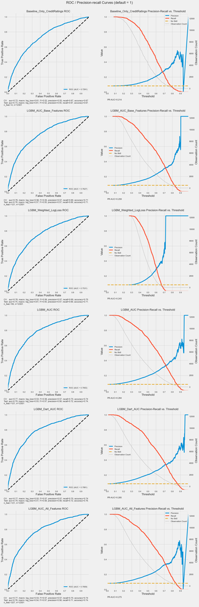

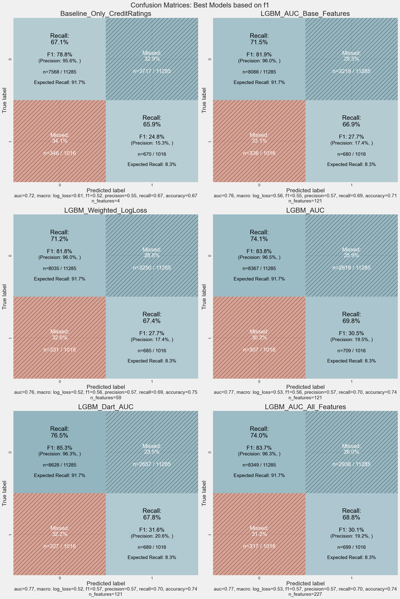

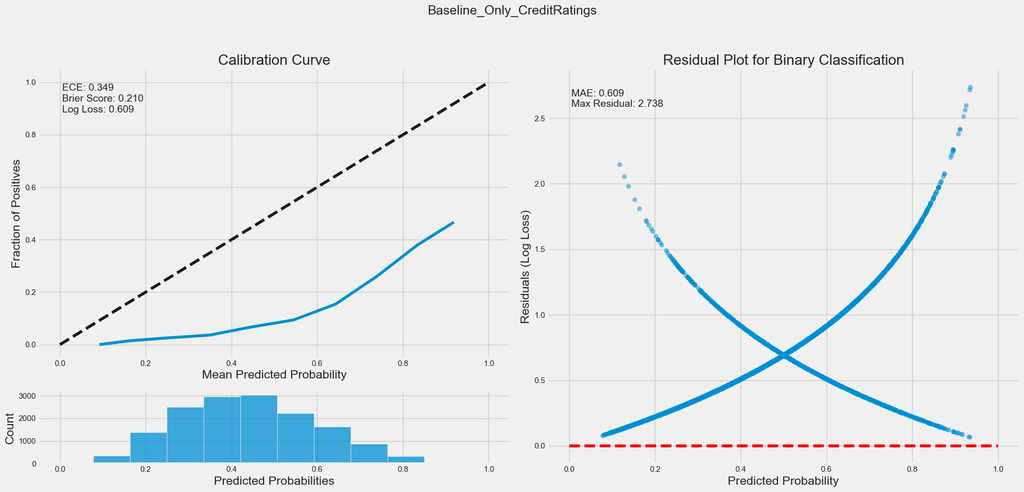

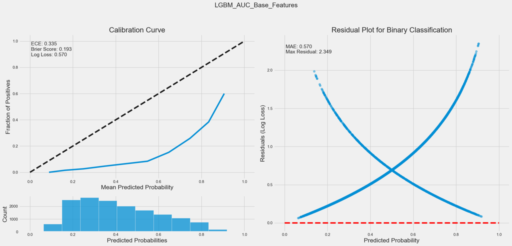

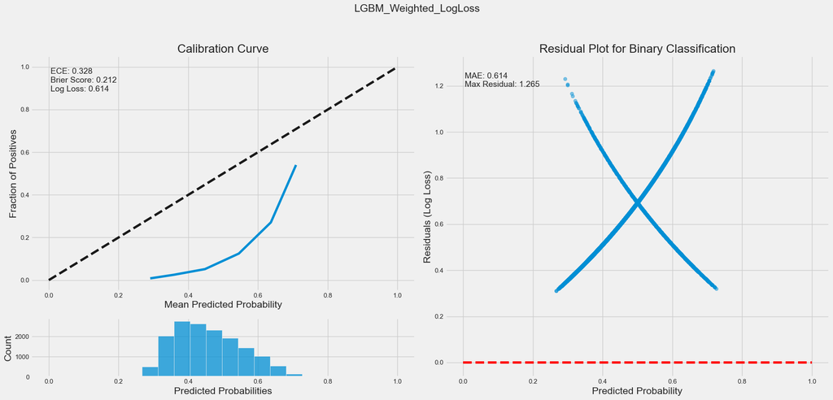

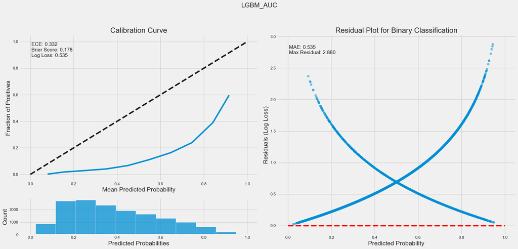

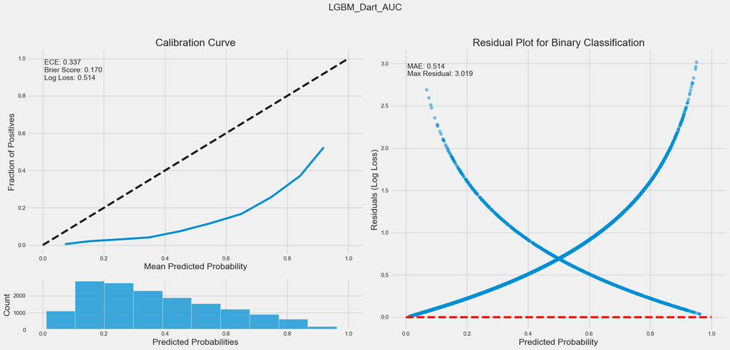

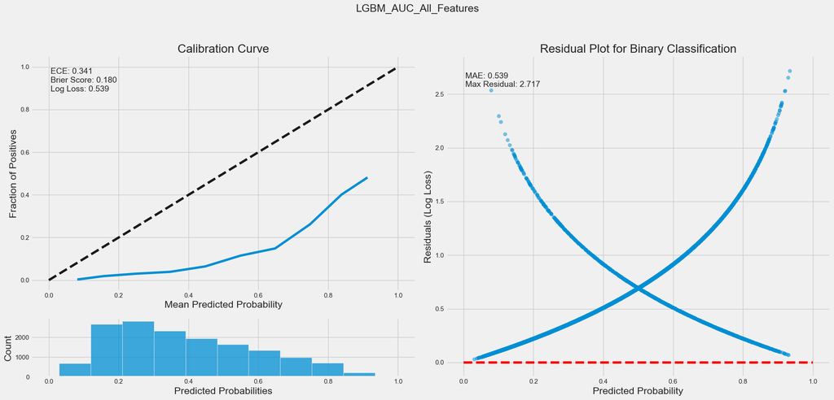

The **calibration curve**, also known as a reliability diagram, is a graphical representation used to evaluate the accuracy of predicted probabilities in classification models. It specifically checks how well the predicted probabilities of a model match the actual outcomes.

The ideal calibration curve is a straight line at a 45-degree angle from the bottom left to the top right of the plot. This line, often called the "line of perfect calibration," indicates that the model's predictions are perfectly calibrated. If your model predicts a class with 70% probability, then 70% of the cases that are predicted as such should indeed belong to that class.

Common Patterns and Their Interpretations: Perfect Calibration:

The points lie on the diagonal line from (0,0) to (1,1). Example: If a model predicts an event with 30% probability, then in the long run, that event occurs about 30% of the time when predicted at this probability. Underconfidence:

The curve lies above the diagonal line. The model's probabilities are lower than the true likelihood of the event. For instance, if events the model predicts to happen 60% of the time actually happen 80% of the time, the model is underconfident. Overconfidence:

The curve lies below the diagonal line. The model predicts higher probabilities than what is true. If a prediction of 80% only happens 60% of the time, the model is overconfident.

*Expected Calibration Error (ECE)*: This measures the average difference between the predicted probabilities and the actual outcomes. Lower values indicate better calibration.

*Brier Score*: Measures the mean squared difference between the predicted probability and the actual outcome. It is a good measure of the accuracy and calibration of the predictions.

**Residual** Plots show the difference between observed and predicted probabilities. Helps in checking the assumption of homoscedasticity. Ideally, residuals should be randomly dispersed around the central line, and patterns suggest model inadequacies.

homoscedasticity

Based on the chart we see these potential problems: Probability Estimates are Polarized:

The cup-like pattern at the top suggests the model is very confident (probabilities close to 0 or 1) about certain instances but is incorrect, as these points have higher residuals. The bottom lines being straighter and closer to zero indicate that for a range of predicted probabilities, the residuals are consistently low, which means the model performs well in that range.

Model Overconfidence:

The residuals are larger for predictions near 0 or 1 because the log loss penalizes confident incorrect predictions more harshly than less confident ones. This overconfidence is often characteristic of models that are not well-calibrated and could benefit from probability calibration techniques.

Class Imbalance:

This pattern can sometimes emerge from class imbalance if the model is better at predicting the majority class and frequently mispredicts the minority class with high confidence.

Non-linearity in Feature Space:

The curving pattern could also be a sign that the model is not capturing some non-linear relationships between features and the outcome. This might suggest that feature engineering or a more sophisticated model could be helpful.

*Mean Absolute Error (MAE)* of Residuals: This is the average of the absolute values of the residuals. It gives an idea of the average magnitude of the prediction errors. Annotation: Indicating MAE on the residual plot can help assess the typical error magnitude in a more intuitive way than just viewing the spread of residuals.

*Maximum Residual*: The maximum value among the residuals can indicate the worst-case scenario for your predictions. Annotation: Marking the maximum residual can alert users to the worst errors the model could make.